# Week 5 Practice

BDS

July 2, 2018

```r
library(mirt)

library(dplyr)
```

We have the same json file that we had last week, so nothing has changed there.

```r
week5 = jsonlite::read_json("C://Users/berry2006/Documents/projects/courses/bds/exerciseData/week04and05.json",
                            simplifyVector = TRUE)
```

As with everything, we need to think through some issues before we just dive right into coding the model up.

What was the nature of our response – dichotomous or polytomous? Once we know, we can make the first decision.

```r
summary(week5)
```

```
##       id             jobTasksSDSA   jobBalanceSDSA    jobPaySDSA
##  Length:1384        Min.   :1.000   Min.   :1.000   Min.   :1.000
##  Class :character   1st Qu.:2.000   1st Qu.:2.000   1st Qu.:4.000
##  Mode  :character   Median :4.000   Median :4.000   Median :6.000
##                     Mean   :4.004   Mean   :4.069   Mean   :5.178
##                     3rd Qu.:6.000   3rd Qu.:6.000   3rd Qu.:7.000
##                     Max.   :7.000   Max.   :7.000   Max.   :7.000
##
##  jobRecognitionSDSA jobAdvancementSDSA jobCoworkersSDSA jobManagementSDSA
##  Min.   :1.000      Min.   :1.00       Min.   :1.000    Min.   :0.000
##  1st Qu.:4.000      1st Qu.:4.00       1st Qu.:4.000    1st Qu.:4.000
##  Median :5.000      Median :5.00       Median :6.000    Median :5.000
##  Mean   :5.173      Mean   :5.21       Mean   :5.259    Mean   :5.174
##  3rd Qu.:7.000      3rd Qu.:7.00       3rd Qu.:7.000    3rd Qu.:7.000
##  Max.   :7.000      Max.   :7.00       Max.   :7.000    Max.   :7.000
##                                                         NA's   :212
```

These are clearly polytomous items, so we are going to be working with a polytomous model. Now, we need to think through our parameters.

```r
week5IRT = week5 %>%
  select(-id) %>%
  mirt(data = ., model = 1,
       itemtype = "graded", verbose = FALSE)

summary(week5IRT)
```

```
##                          F1       h2
## jobTasksSDSA        0.99959 9.99e-01
## jobBalanceSDSA     -0.00413 1.70e-05
## jobPaySDSA          0.98071 9.62e-01
## jobRecognitionSDSA  0.98060 9.62e-01
## jobAdvancementSDSA  0.98231 9.65e-01
## jobCoworkersSDSA    0.00027 7.28e-08
## jobManagementSDSA  -0.03471 1.20e-03
##
## SS loadings:  3.889
## Proportion Var:  0.556
##
## Factor correlations:
##
##    F1
## F1  1
```

Let’s peak at our item trace lines.

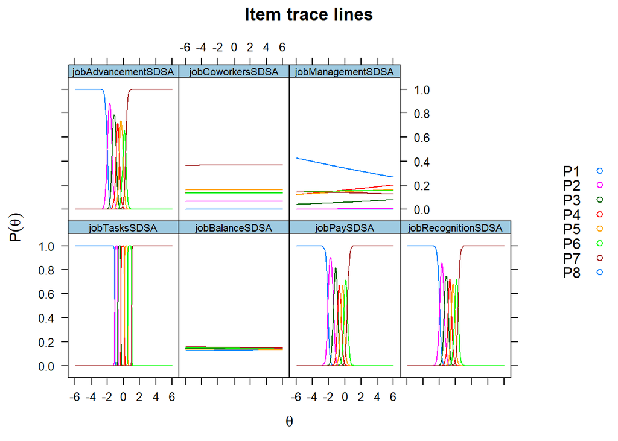

```r
plot(week5IRT, type = "trace")
```

We clearly have some items that are not providing much information! Some items, however, have response options that appear to discriminate pretty well over the range of $\theta$.

Remember, though, that our factor analysis from last week yielded a pretty good solution with two factors. We should probably take that into account here.

While we did not get much into the exploratory/confirmatory distinction, we can do both here.

Here, we are just specifying two factors and our model will do the rest (this is exploratory).

```r
week5IRT2Factor = week5 %>%
  select(-id) %>%
  mirt(data = ., model = 2,
       itemtype = "graded", verbose = FALSE)

summary(week5IRT2Factor, rotate = "promax")
```

```
##
## Rotation:  promax
##
## Rotated factor loadings:
##
##                          F1        F2      h2
## jobTasksSDSA        0.99900 -0.019165 0.99856
## jobBalanceSDSA     -0.00234 -0.998047 0.99608
## jobPaySDSA          0.98096  0.006778 0.96226
## jobRecognitionSDSA  0.98096 -0.002515 0.96232
## jobAdvancementSDSA  0.98302  0.015297 0.96641
## jobCoworkersSDSA    0.00336 -0.984720 0.96972
## jobManagementSDSA  -0.04914 -0.000771 0.00241
##
## Rotated SS loadings:  3.891 1.966
##
## Factor correlations:
##
##        F1     F2
## F1  1.000 -0.005
## F2 -0.005  1.000
```

Our first factor looks pretty good, but the second factor is a bit different.

If we want to go the confirmatory route, we would do something like the following:

```r
confirmatoryModel = mirt.model('
   F1 = 1,3,4,5
   F2 = 2,6,7')

week5IRTConfirmatory = week5 %>%
  select(-id) %>%
  mirt(data = ., model = confirmatoryModel,
       itemtype = "graded", verbose = FALSE)
```

Let’s also compare our single factor model to our exploratory two factor model.

```r
anova(week5IRT, week5IRT2Factor)
```

```
##
## Model 1: mirt(data = ., model = 1, itemtype = "graded", verbose = FALSE)
## Model 2: mirt(data = ., model = 2, itemtype = "graded", verbose = FALSE)
```

```
##        AIC     AICc    SABIC       HQ      BIC    logLik       X2  df   p
## 1 24961.38 24965.21 25064.19 25059.24 25223.02 -12430.69      NaN NaN NaN
## 2 21966.09 21970.90 22081.23 22075.69 22259.12 -10927.05 3007.293   6   0
```

Given the fits, the two factor model is definitely better.